# FigureYa174squareCross

小丫画图出品

2020-4-19

欢迎关注“小丫画图”公众号，回复“小白”，看小视频，实现点鼠标跑代码。

小丫微信: epigenomics E-mail: figureya@126.com

作者：hazard

小丫编辑校验

# 需求描述

这篇文章自带的R代码里没找到这张图的代码…… 我其实就想要基因表达和药物连线，他右侧target 和pathway的连线。 感觉用的地方其实挺多的，想学学连线的方法。

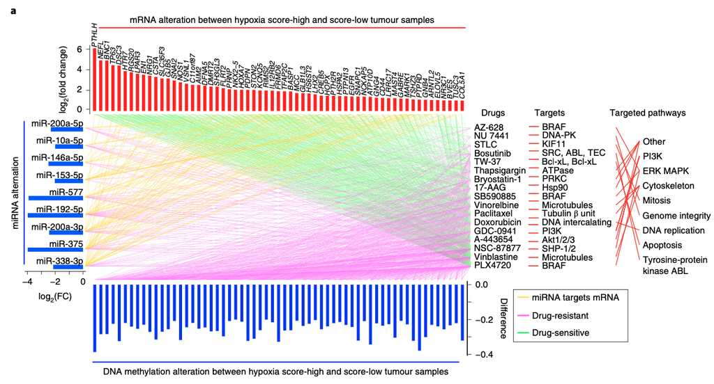

出自https://doi.org/10.1038/s42255-019-0045-8

Fig. 5 | Effects of multidimensional hypoxia-associated signatures on drug response. a, Interaction of hypoxia-associated mRNAs, DNA methylation, miRNAs and drug response. Upregulated genes (red bars in upper panel) in hypoxia score-high ESCA negatively correlate (green lines, drug-sensitive) with the response to 17 drugs. Downregulated miRNAs (blue bars, left panel), hypomethylation (blue bars, bottom panel) for the corresponding upregulated genes positively correlate (magenta lines, drug-resistant) to drug response. The target genes and targeted pathways of drugs are listed in the panel to the right. The gold line indicates miRNA-targeted mRNAs; the red line links the drug to its target and targeted pathway. DNA-PK, DNA-dependent protein kinase; Hsp90, heat shock protein 90; KIF11, kinesin family member 11; PRKC, serine/threonine-protein kinase; SHP-1/2, Src homology 2 domain- containing protein tyrosine phosphatase 1/2; STLC, S-trityl-l-cysteine.

# 应用场景

任意两组、多组连线。

多列或上下左右的排布方式。

根据自己数据的生物学意义，来排列各个节点的顺序。或许能够出现特殊的模式，从而展示出有意义的生物学规律。

# 环境设置

使用国内镜像安装包

```r
options("repos"= c(CRAN="https://mirrors.tuna.tsinghua.edu.cn/CRAN/"))
options(BioC_mirror="http://mirrors.ustc.edu.cn/bioc/")
devtools::install_github("zzwch/crosslinks")
install.packages("aplot")
```

加载包

```r
library(ggplot2)
library(aplot)
library(dplyr)
library(crosslinks)

Sys.setenv(LANGUAGE = "en") #显示英文报错信息
options(stringsAsFactors = FALSE) #禁止chr转成factor
```

# 输入文件

easy_input_nodes.txt，所有节点id及其类别type。

easy_input_edges.txt，每两个被连起来的节点为一行。

```r
# 载入连线所需的节点类型
nodes <- read.table("easy_input_nodes.txt", header = T)
head(nodes)
```

```
##      id type
## 1 Gene1 Gene
## 2 Gene2 Gene
## 3 Gene3 Gene
## 4 Gene4 Gene
## 5 Gene5 Gene
## 6 Gene6 Gene
```

```r
table(nodes$type)
```

```
##
## Drug Gene Meth  Mir Path  Tar
##    8   10   10    6    6    8
```

```r
# 载入连线所需的节点间的关系
edges <- read.table("easy_input_edges.txt", header = T)
head(edges)
```

```
##   source target
## 1  Gene6   Mir3
## 2  Gene2   Mir1
## 3  Gene3   Mir5
## 4  Gene1   Mir4
## 5  Gene6   Mir6
## 6  Gene9   Mir6
```

为了画上下左三面的bar plot，需提供节点对应的数值：

- easy_input_geneData.txt
- easy_input_methData.txt
- easy_input_mirData.txt

```r
# 载入画bar plot所需的数值
geneData <- read.table("easy_input_geneData.txt", header = T)
head(geneData)
```

```
##    gene        lfc
## 1 Gene1 2.03845613
## 2 Gene2 0.43505296
## 3 Gene3 0.02458533
## 4 Gene4 4.34067861
## 5 Gene5 1.79503682
## 6 Gene6 4.20195310
```

```r
methData <- read.table("easy_input_methData.txt", header = T)
head(methData)
```

```
##    meth        lfc
## 1 Meth1 -0.4845682
## 2 Meth2 -0.2629383
## 3 Meth3 -0.3447941
## 4 Meth4 -0.2046605
## 5 Meth5 -0.2672850
## 6 Meth6 -0.4343072
```

```r
mirData <- read.table("easy_input_mirData.txt", header = T)
head(mirData)
```

```
##    mir        lfc
## 1 Mir1 -0.1800233
## 2 Mir2 -3.7385375
## 3 Mir3 -0.4348398
## 4 Mir4 -3.0869569
## 5 Mir5 -0.3048245
## 6 Mir6 -1.3052404
```

## 左右连线（列之间）

左右多列之间连线，用columnCross函数来画。

两列

```r
columns <- list(
  Target = nodes$id[nodes$type == "Tar"], # set the order as you like
  Pathway = nodes$id[nodes$type == "Path"]# set the order as you like
)
columns
```

```
## $Target
## [1] "Tar1" "Tar2" "Tar3" "Tar4" "Tar5" "Tar6" "Tar7" "Tar8"
##
## $Pathway
## [1] "Path1" "Path2" "Path3" "Path4" "Path5" "Path6"
```

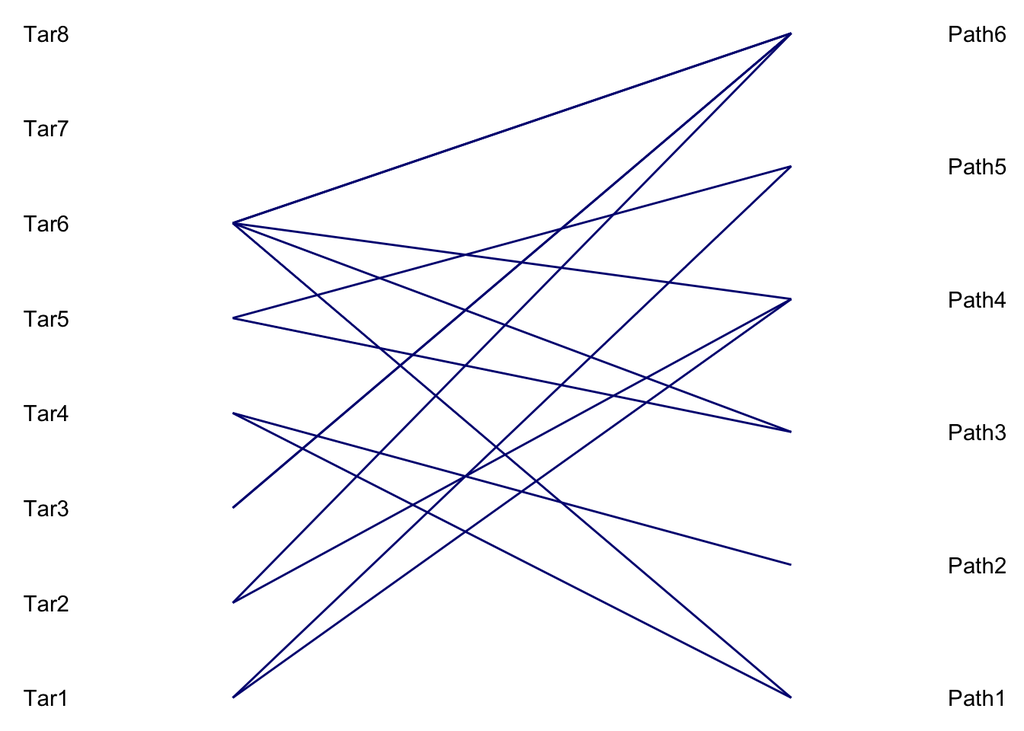

```r
columnCross(edges, columns, height = 10, flank_mult = 0.1, segment_shrink = 0.2) +
     scale_color_manual(values = "navy") # 自定义线的颜色
```

```r
ggsave("squareCross_2.pdf", width = 5, height = 5)
```

三列

```r
columns <- list(
  #用输入文件中的默认顺序
  Drug = nodes$id[nodes$type == "Drug"],
  #也可以换成下面这行，手动按自己想要的顺序写入
  #Drug = c("Drug3", "Drug2", "Drug1", "Drug4", "Drug5", "Drug8", "Drug7", "Drug6"),
  Target = nodes$id[nodes$type == "Tar"], # set the order as you like
  Pathway = nodes$id[nodes$type == "Path"]# set the order as you like
)
columns
```

```
## $Drug
## [1] "Drug1" "Drug2" "Drug3" "Drug4" "Drug5" "Drug6" "Drug7" "Drug8"
##
## $Target
## [1] "Tar1" "Tar2" "Tar3" "Tar4" "Tar5" "Tar6" "Tar7" "Tar8"
##
## $Pathway
## [1] "Path1" "Path2" "Path3" "Path4" "Path5" "Path6"
```

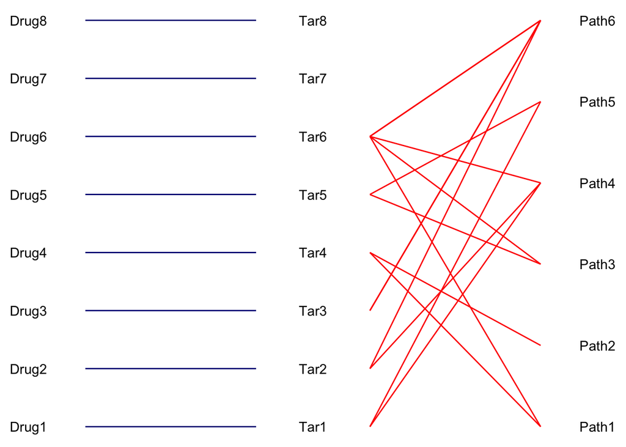

```r
columnCross(edges, columns, height = 10, flank_mult = 0.1, segment_shrink = 0.2) +
  scale_color_manual(values = c("navy","red")) # 自定义线的颜色
```

```r
ggsave("squareCross_3.pdf", width = 5, height = 5)
```

四列

```r
columns <- list(
  Gene = nodes$id[nodes$type == "Gene"],
  Drug = nodes$id[nodes$type == "Drug"],
  Target = nodes$id[nodes$type == "Tar"], # set the order as you like
  Pathway = nodes$id[nodes$type == "Path"]# set the order as you like
)
columns
```

```
## $Gene
##  [1] "Gene1"  "Gene2"  "Gene3"  "Gene4"  "Gene5"  "Gene6"  "Gene7"  "Gene8"
##  [9] "Gene9"  "Gene10"
##
## $Drug
## [1] "Drug1" "Drug2" "Drug3" "Drug4" "Drug5" "Drug6" "Drug7" "Drug8"
##
## $Target
## [1] "Tar1" "Tar2" "Tar3" "Tar4" "Tar5" "Tar6" "Tar7" "Tar8"
##
## $Pathway
## [1] "Path1" "Path2" "Path3" "Path4" "Path5" "Path6"
```

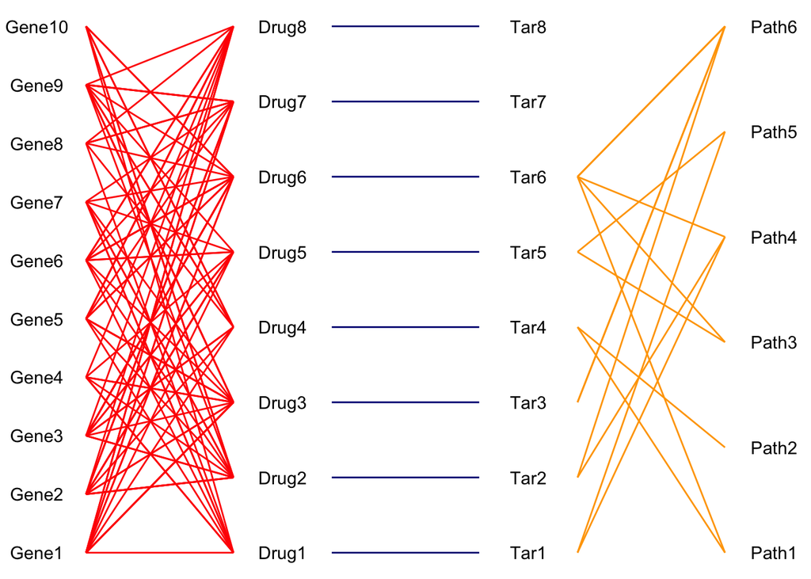

```r
columnCross(edges, columns, height = 10, flank_mult = 0.1, segment_shrink = 0.2) +
  scale_color_manual(values = c("navy","red","orange")) # 自定义线的颜色
```

```r
ggsave("squareCross_4.pdf", width = 6, height = 5)
```

## 上下左右连线（行、列之间）

上下左右连线，用squareCross函数来画

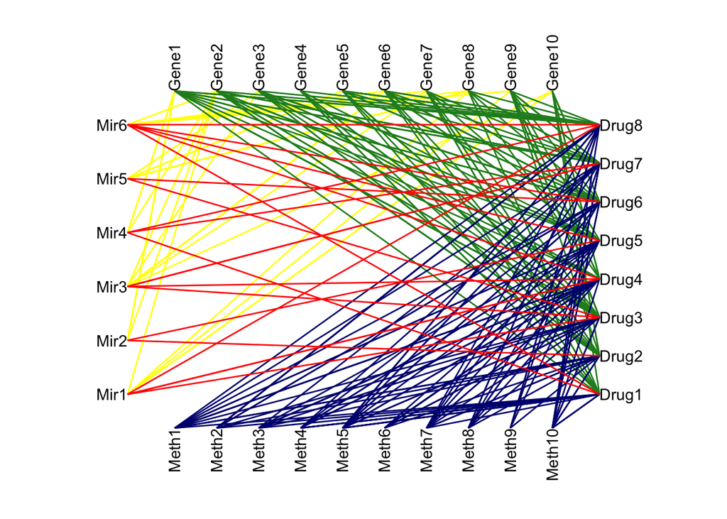

```r
top <- nodes$id[nodes$type == "Gene"] # set the order as you like
bottom <- nodes$id[nodes$type == "Meth"] # set the order as you like
left <- nodes$id[nodes$type == "Mir"] # set the order as you like
right <- nodes$id[nodes$type == "Drug"] # set the order as you like

squareCross(edges, top ,bottom, left, right,
            height = 10, width = 10, flank_mult = 0.1,
            show_node_label = T) + # 显示node label
  # 自定义线的颜色
  scale_color_manual(values = c("navy", "red", "yellow", "forestgreen"))
```

```r
ggsave("squareCross_22.pdf", width = 5, height = 5)
```

## 复现原图

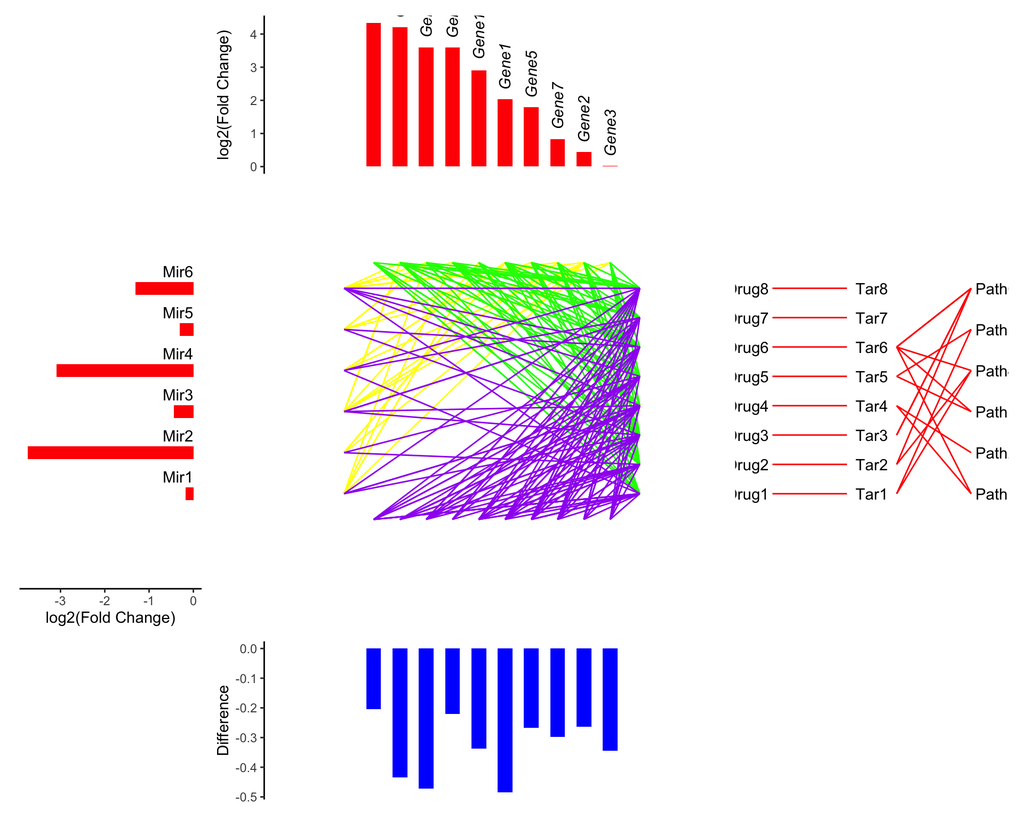

```r
# 例文顶部按基因变化倍数从高到低排序，底部跟顶部一致
top <- geneData$gene[order(geneData$lfc, decreasing = T)] # set the order as you like
bottom <- methData$meth[order(geneData$lfc, decreasing = T)] # In this case, Meth should be the same order with Gene
left <- nodes$id[nodes$type == "Mir"] # set the order as you like
right <- nodes$id[nodes$type == "Drug"] # set the order as you like

# 右侧要画的3列
columns <- list(
  Drug = nodes$id[nodes$type == "Drug"], # set the order as you like
  Target = nodes$id[nodes$type == "Tar"], # set the order as you like
  Pathway = nodes$id[nodes$type == "Path"]# set the order as you like
)

height <- 10
width <- 10
flank_mult <- c(top = 0.1, bottom = 0.1,left = 0.1, right = 0.1)

# 先分别画出3个bar plot
topAnn <- geneData %>%
  mutate(gene_f = factor(gene, top)) %>%
  ggplot(mapping = aes(
    newCoord(gene_f, width, flank_mult[['top']]),
    lfc)) +
  geom_bar(fill = "red",
           stat = "identity",
           width = 0.5) + # 间距跟bar同宽
  geom_text(mapping = aes(label = gene), angle = 90, hjust =-0.2, fontface ="italic") +
  labs(x = NULL, y = "log2(Fold Change)") +
  theme_classic() +
  theme(axis.text.x = element_blank(),
        axis.line.x = element_blank(),
        axis.ticks.x = element_blank())
#topAnn

# Bottom plot
botAnn <- methData %>%
  mutate(meth_f = factor(meth, bottom)) %>%
  ggplot(mapping = aes(newCoord(meth_f, width, flank_mult[['bottom']]),
                       lfc)) +
  geom_bar(fill = "blue",
           stat = "identity",
           width = 0.5) +
  #geom_text(mapping = aes(label = gene), angle = 90, hjust =-0.2, fontface ="italic") +
  labs(x = NULL, y = "Difference") +
  theme_classic() +
  theme(axis.text.x = element_blank(),
        axis.line.x = element_blank(),
        axis.ticks.x = element_blank())
#botAnn

# left plot
lftAnn <- mirData %>%
  mutate(mir_f = factor(mir, left)) %>%
  ggplot(mapping = aes(newCoord(mir_f, height, flank_mult[['left']]),
                       lfc)) +
  geom_bar(fill = "red",
           stat = "identity",
           width = 0.5) +
  geom_text(mapping = aes(y = 0,label = mir),
            #fontface ="italic",
            vjust = -1,
            hjust = 1) +
  labs(x = NULL, y = "log2(Fold Change)") +
  theme_classic() +
  theme(axis.text.y = element_blank(),
        axis.line.y = element_blank(),
        axis.ticks.y = element_blank()) +
  coord_flip()
#lftAnn

# 画连线并跟3个bar plot拼一起
p <- (squareCross(edges, top ,bottom, left, right, height = 10, width = 10, flank_mult = 0.1) +
        #自定义配色，例文把miRNA和DNA甲基化都归为resistant，因此这两个方向的连线都用了紫色
        #实际应用时，根据自己数据的意义调整颜色
        scale_color_manual(values = c("purple", "purple", "yellow", "green"))) %>%
  insert_top(topAnn, 0.4) %>%
  insert_bottom(botAnn, 0.4) %>%
  insert_left(lftAnn, 0.4) %>%

  # 在右侧加入多列之间的连线
  insert_right(columnCross(edges, columns, height = 10, flank_mult = 0.1, segment_shrink = 0.2) +
     scale_color_manual(values = c("red", "red")) , 0.6)
p
```

```r
ggsave(plot = p, filename = "squarecross.pdf", width = 8, height = 5)
```

# 后期处理

输出的pdf文件是矢量图，可以用矢量图编辑器打开（例如Illustrator）调整图形、文字。

# 附：示例数据生成过程

```r
# nodes
nodes <- data.frame(
  id = c(paste0("Gene", 1:10), paste0("Meth", 1:10),
         paste0("Mir", 1:6), paste0("Drug", 1:8),
         paste0("Tar", 1:8), paste0("Path", 1:6)),
  type = c(rep("Gene", 10), rep("Meth", 10),
           rep("Mir", 6), rep("Drug", 8),
           rep("Tar", 8), rep("Path", 6))
  )
# 保存到文件
write.table(nodes, "easy_input_nodes.txt", quote = F, sep = "\t", row.names = F)

# edges
edges <- data.frame(rbind(
  # gene vs mir
  data.frame(
    source = sample(nodes$id[nodes$type == "Gene"],
                    replace = T, 30),
    target = sample(nodes$id[nodes$type == "Mir"],
                    replace = T, 30)),
  # gene vs drug
  data.frame(
    source = sample(nodes$id[nodes$type == "Gene"],
                    replace = T, 100),
    target = sample(nodes$id[nodes$type == "Drug"],
                    replace = T, 100)),
  # meth vs drug
  data.frame(
    source = sample(nodes$id[nodes$type == "Meth"],
                    replace = T, 100),
    target = sample(nodes$id[nodes$type == "Drug"],
                    replace = T, 100)),
  # mir vs drug
  data.frame(
    source = sample(nodes$id[nodes$type == "Mir"],
                    replace = T, 20),
    target = sample(nodes$id[nodes$type == "Drug"],
                    replace = T, 20)),

  # drug vs target
  data.frame(
    source = nodes$id[nodes$type == "Drug"],
    target = nodes$id[nodes$type == "Tar"]),
  # target vs path
  data.frame(
    source = sample(nodes$id[nodes$type == "Tar"],
                    replace = T, 15),
    target = sample(nodes$id[nodes$type == "Path"],
                    replace = T, 15))
))
write.table(edges, "easy_input_edges.txt", quote = F, sep = "\t", row.names = F)

# gene annotation
geneData <- data.frame(
  gene = nodes$id[nodes$type == "Gene"],
  lfc = runif(length(nodes$id[nodes$type == "Gene"]), 0, 6))
write.table(geneData, "easy_input_geneData.txt", quote = F, sep = "\t", row.names = F)

# meth annotation
methData <- data.frame(
  meth = nodes$id[nodes$type == "Meth"],
  lfc = runif(length(nodes$id[nodes$type == "Meth"]), -0.5, -0.2))
write.table(methData, "easy_input_methData.txt", quote = F, sep = "\t", row.names = F)

# mir annotation
mirData <- data.frame(
  mir = nodes$id[nodes$type == "Mir"],# set the order as you want
  lfc = runif(length(nodes$id[nodes$type == "Mir"]), -4,0))
write.table(mirData, "easy_input_mirData.txt", quote = F, sep = "\t", row.names = F)
```